# EQ6_TP2_Q1_analyse

Antonio Collante Caro (111 227 429)

Luc Grenier (902 201 689)

03 November, 2019

# 1 Estimation de l’efficacité d’une opération de recherche en mer

Comme mentionné dans l’énoncé, nous devons jouer le rôle d’analyste pour un groupe responsable de recherche et sauvetage maritime.

## 1.1 Préparer les données

Dans cette section, nous devions faire un prétraitement avant d’appeler la fonction `train`.

```
## [1] "data/Q1_data.txt"
```

Après la préparation, les données montraient 0 donnée manquante.

Voici quelques lignes:

```
##    in01 in02     in03      in04    in05     in06  in07 in08     in09
## 1  1.35    5 779.2968  89.70183 136.861 -59.7808  4.75 3.89  8.09035
## 2  1.30    5 313.8710 141.42008 316.865 -59.7771  5.08 4.15  8.36471
## 3  1.18    5 650.3987  85.92002 316.880 -59.7676  6.20 5.07  9.24122
## 4  0.74    3 193.4001 120.08588 316.886 -60.3266  6.73 5.50  9.62451
## 5  0.68    3 215.6881 127.30805 316.899 -60.3588  7.92 6.48 10.44490
## 6  0.67    3 150.5078 118.57004 316.903 -60.3677  8.26 6.76 10.66360
## 7  0.63    3 173.1099  98.92309 316.911 -60.3900  9.13 7.47 11.20970
## 8  0.59    3 602.7458 128.98833 316.924 -60.4217 10.42 8.53 11.97360
## 9  1.37    5 629.8254 176.15330 316.861 -59.7825  4.62 3.78  7.98078
## 10 1.36    5 247.1228 149.95515 136.862 -59.7816  4.68 3.83  8.03545
##        in10     in11  in12 in13    in14    in15 in16 in17    in18    in19
## 1  103.0660 -60.2279 284.3    2 45.3751 136.852 2.37    3 284.338 44.9233
## 2  106.4940 -60.2353 304.0    2 45.3821 136.852 2.53    3 303.983 44.9140
## 3  117.4120 -60.2590 371.2    2 45.4038 136.852 3.09    3 371.195 44.8833
```

[output cut: 18 more lines]

Les types de colonnes sont corrects, certains sont des entiers et d’autres des nombres naturels, tel qu’illustrer ci contre:

```
## 'data.frame':    3576 obs. of  23 variables:
##  $ in01   : num  1.35 1.3 1.18 0.74 0.68 0.67 0.63 0.59 1.37 1.36 ...
##  $ in02   : int  5 5 5 3 3 3 3 3 5 5 ...
##  $ in03   : num  779 314 650 193 216 ...
##  $ in04   : num  89.7 141.4 85.9 120.1 127.3 ...
##  $ in05   : num  137 317 317 317 317 ...
##  $ in06   : num  -59.8 -59.8 -59.8 -60.3 -60.4 ...
##  $ in07   : num  4.75 5.08 6.2 6.73 7.92 ...
##  $ in08   : num  3.89 4.15 5.07 5.5 6.48 6.76 7.47 8.53 3.78 3.83 ...
##  $ in09   : num  8.09 8.36 9.24 9.62 10.44 ...
##  $ in10   : num  103.1 106.5 117.4 80.3 86.9 ...
##  $ in11   : num  -60.2 -60.2 -60.3 -60.3 -60.3 ...
##  $ in12   : num  284 304 371 403 474 ...
##  $ in13   : int  2 2 2 1 1 1 1 1 2 2 ...
##  $ in14   : num  45.4 45.4 45.4 45.4 45.4 ...
##  $ in15   : num  137 137 137 137 137 ...
##  $ in16   : num  2.37 2.53 3.09 3.36 3.95 4.12 4.56 5.2 2.31 2.34 ...
##  $ in17   : int  3 3 3 2 2 2 2 2 3 3 ...
##  $ in18   : num  284 304 371 403 474 ...
##  $ in19   : num  44.9 44.9 44.9 45.4 45.4 ...
##  $ in20   : num  2.37 2.53 3.09 3.36 3.95 4.12 4.56 5.2 2.31 2.34 ...
##  $ in21   : num  35.1 36.3 40.2 41.8 45.4 ...
##  $ in22   : num  32.8 33.8 37.1 38.5 41.5 ...
##  $ outcome: num  0.944 0.913 0.814 0.694 0.533 ...
```

## 1.2 Entraînement

Pour nos grids, nous avons utilisé ces paramètres:

knn: `expand.grid(k= seq(1,100,by = 2))`

nnet: `expand.grid(decay = c(0.01, 0.5, 0.1), size = c(1:10))`

Ces paramètres du grid nous ont permis de trouver les bons paramètres pour l’entrainement, ceci sera expliqué dans le prochain point.

De plus, nous avons retiré certaines colonnes qui représentaient une trop grande corrélation entre elles, le cutoff a été établi à .75. Nous avons créé aussi les partitions selon la règle 80:20. Et, nous avons établi le nombre de validations croisées à 10 pour knn et à 22 pour nnet.

```
## [1] "knn"
## [1] "Load model from file"
```

```
## [1] "nnet"
## [1] "Load model from file"
```

## 1.3 Évaluation de l’entraînement pour chaque modèle individuel

### 1.3.1 Méthode des k plus proches voisins (knn)

La Figure 1 montre la valeur de RMSE selon la valeur du nombre de plus proche voisin choisi (k). Nous pouvons constater que le modèle devient rapidement surentrainé. En effet, 5 est la meilleure valeur pour le paramètre k (nombre de voisins) ici. On peut constater qu’à partir de la valeur 7, le RMSE augmente. Nous obtenons un RMSE de 0.0409927 pour ce modèle.

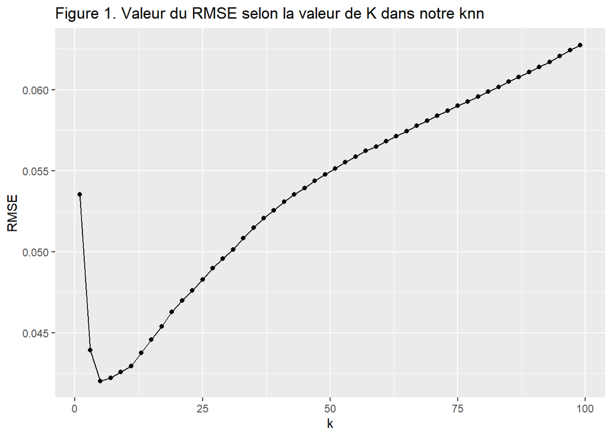

La Figure 2 présente l’histogramme de la distribution des résidus des données d’entrainement. Nous pouvons constater que l’ensemble des valeurs tournent autour de 0. Toutefois, nous pouvons réaliser que le modèle a tendance à davantage sous-évalué que de sur évalué. En effet, nous pouvons trouver des valeurs allant jusqu’à -0,2 pour la sous-évaluation, comparativement à 0,1 pour la sur évaluation.

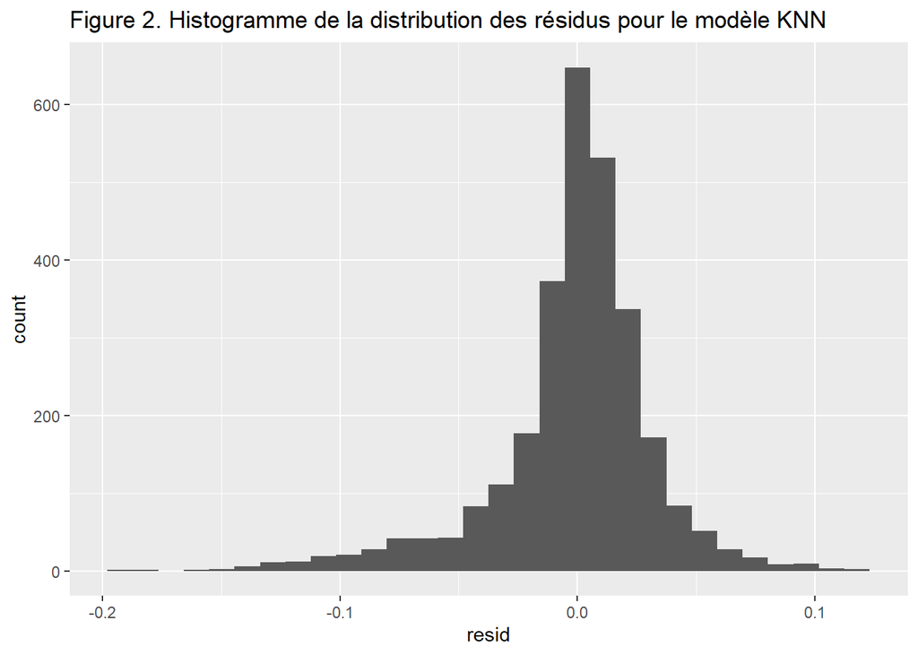

La Figure 3 présente la distribution dans l’espace des résidus des données d’entrainement. Nous pouvons constater que le nuage de point est relativement diffu autour de 0. En effet, pour les valeurs de x<~65, les points semblent assez dispersés entre -0,1 et 0,1. De plus, il y a certains points sous la valeur de -0,1. Toutefois, pour les valeurs de x>~65, les points se rapprochent davantage de 0.

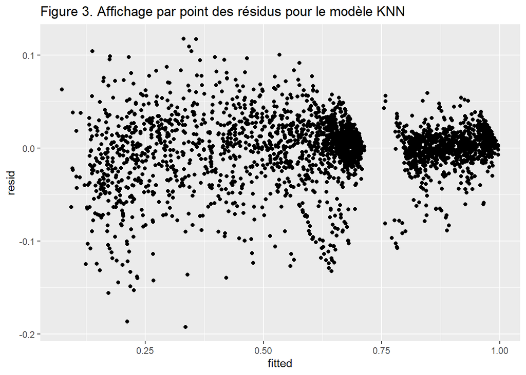

### 1.3.2 Méthode des réseaux de neurones (nnet)

La figure 4 montre la valeur de RMSE selon la veleur du nombre d’unités cachées (size) pour chacun des poids des *decay*. Nous pouvons constater qu’avec un *decay* de 0.01, les RMSE sont plus bas. De plus, le RMSE semble se stabiliser à partir du pramètre *size* égal à 6, mais la valeur de *size* qui présente le meilleur RMSE est 8. Ainsi, nos meilleures valeurs de paramètre sont size=8 et decay=0.01. Ceci nous amène à une valeur de RMSE de 0.0276523.

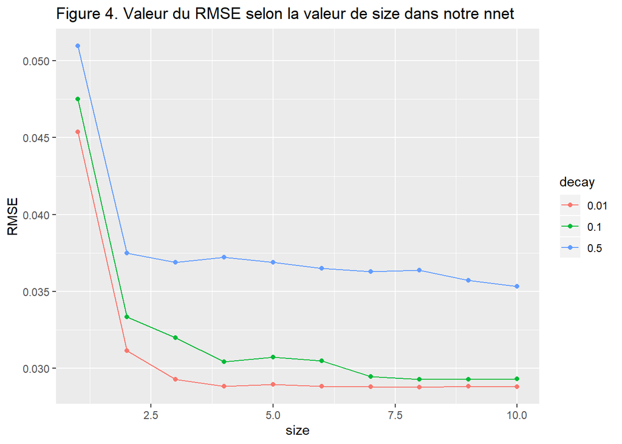

La Figure 5 présente l’histogramme de la distribution des résidus des données d’entrainement. Nous pouvons constater que l’ensemble des valeurs tournent autour de 0. Toutefois, nous pouvons réaliser que le modèle a tendance à davantage sous évalué que de sur évalué. En effet, nous pouvons trouver des valeurs allant sous -0,2 pour la sous-évaluation, comparativement à 0,05 pour la sur évaluation.

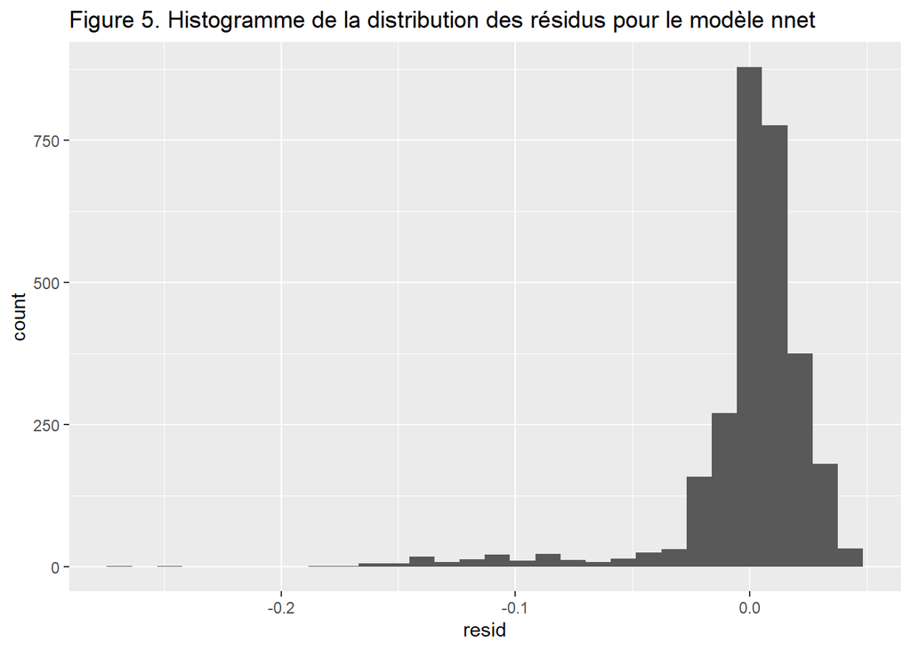

La Figure 6 présente la distribution dans l’espace des résidus des données d’entrainement. Nous pouvons constater que le nuage de points est légèrement diffu, mais relativement près de 0. En effet, il n’y a pas beaucoup de résidus sous les -0,05 et aucun au-dessus de 0,05. Toutefois, il y a deux résidus qui se trouvent sous les -0,2.

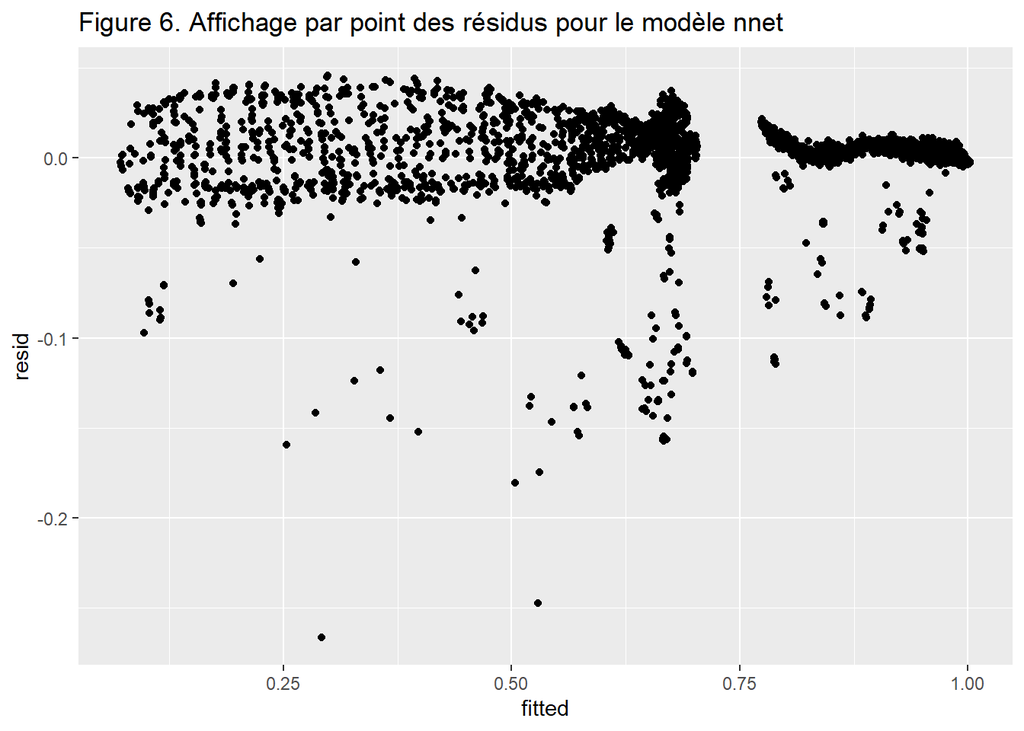

## 1.4 Comparaison des deux modèles

De plus, les résultats après le recalcule les modèles montrent que **le modèle nnet est plus performant** que le modèle knn en comparant les valeurs de RMSE de **0.0276523 et 0.0409927** respectivement. Il est à mentionner que les valeurs de *Rsquared* sont près de 1 pour les deux modèles, mais davantage pour le modèle nnet.

Calcule de la performance de knn

```
##       RMSE   Rsquared        MAE
## 0.04099272 0.96968988 0.02839442
```

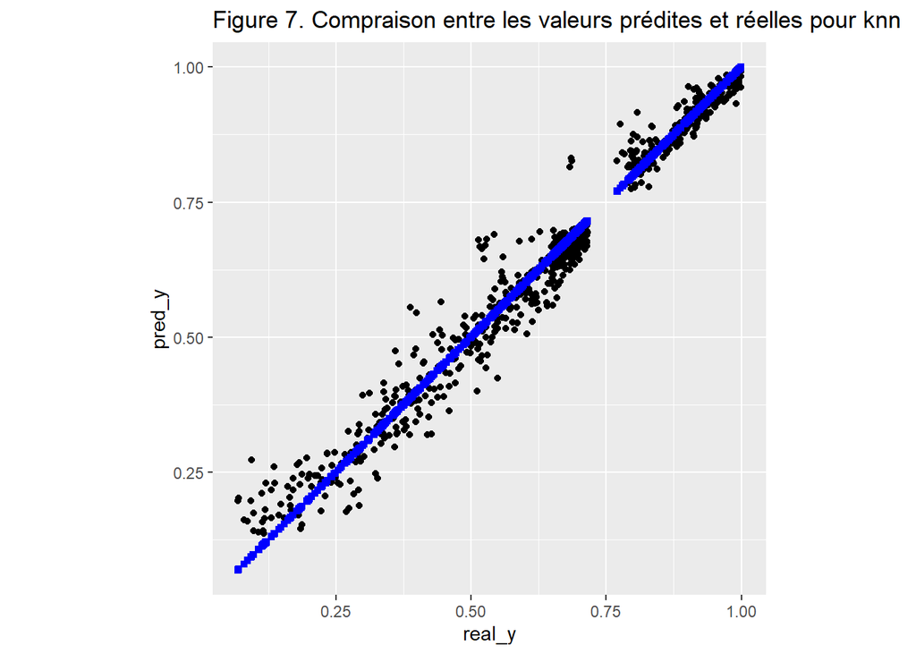

Calcule de la performance de nnet

```
##       RMSE   Rsquared        MAE
## 0.02765225 0.98623813 0.01632343
```

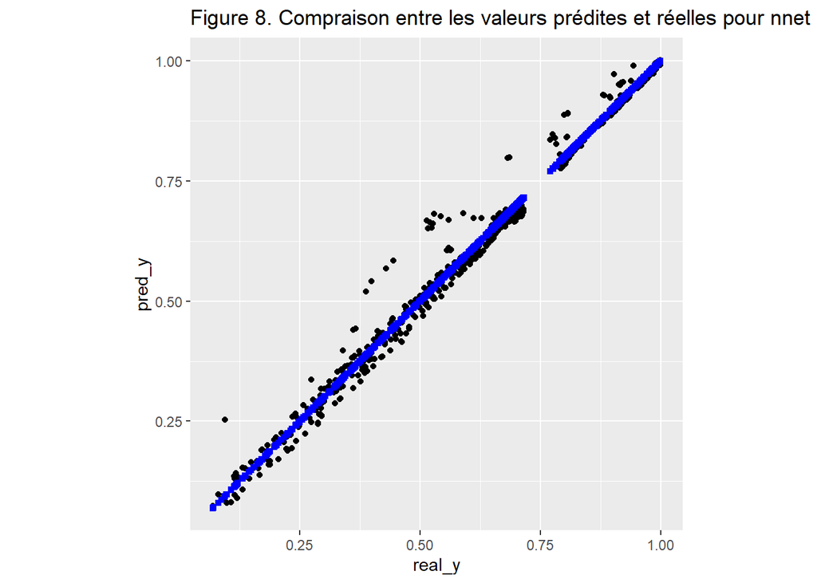

## 1.5 Compétition.. en production (bonus)

Suite aux calculs de la performance pour les modèles nnet et knn, nous avons conclu que nnet est le meilleur modèle. Nom du ficher qui contient le meilleur modèle: **Q1_challenger_T6_nnet.rds**

```
## [1] "Q1_challenger_T6_nnet.rds"
```

```
## [1] "# Training model best tune"
##   size decay
## 8    8  0.01
## [1] "Train Model Perfomance"
## Neural Network
##
## 2864 samples
##    6 predictor
##
## Pre-processing: centered (6), scaled (6)
## Resampling: Cross-Validated (22 fold)
## Summary of sample sizes: 2733, 2733, 2732, 2734, 2733, 2732, ...
## Resampling results across tuning parameters:
##
##   decay  size  RMSE        Rsquared   MAE
##   0.01    1    0.04536857  0.9654565  0.03345589
##   0.01    2    0.03112962  0.9836734  0.02045469
##   0.01    3    0.02926738  0.9854910  0.01753069
##   0.01    4    0.02882737  0.9859149  0.01708273
##   0.01    5    0.02892319  0.9858348  0.01716205
##   0.01    6    0.02882818  0.9859106  0.01696519
##   0.01    7    0.02877306  0.9859723  0.01686332
##   0.01    8    0.02877004  0.9859526  0.01679441
##   0.01    9    0.02880499  0.9859286  0.01682320
##   0.01   10    0.02879539  0.9859459  0.01683652
##   0.10    1    0.04750051  0.9621578  0.03521543
##   0.10    2    0.03333065  0.9813806  0.02397612
##   0.10    3    0.03197888  0.9828407  0.02167756
##   0.10    4    0.03042393  0.9843213  0.01969620
##   0.10    5    0.03072491  0.9841854  0.01996442
##   0.10    6    0.03046476  0.9843182  0.01949316
##   0.10    7    0.02945273  0.9853190  0.01843066
##   0.10    8    0.02926936  0.9855056  0.01786108
##   0.10    9    0.02926977  0.9855195  0.01757069
##   0.10   10    0.02929218  0.9855066  0.01781899
##   0.50    1    0.05098766  0.9565298  0.03797305
##   0.50    2    0.03749701  0.9765297  0.02800758
##   0.50    3    0.03687839  0.9773320  0.02762725
##   0.50    4    0.03720628  0.9768579  0.02788675
##   0.50    5    0.03689378  0.9773257  0.02746001
##   0.50    6    0.03648072  0.9777877  0.02720477
##   0.50    7    0.03629742  0.9780918  0.02692096
##   0.50    8    0.03638129  0.9778106  0.02703099
##   0.50    9    0.03570574  0.9787431  0.02601396
##   0.50   10    0.03530911  0.9791511  0.02560254
##
## RMSE was used to select the optimal model using the smallest value.
## The final values used for the model were size = 8 and decay = 0.01.
## [1] "# RMSE"
## [1] 0.02765225
## [1] "postResample: "
##       RMSE   Rsquared        MAE
## 0.02765225 0.98623813 0.01632343
```